# Practical 6: Mixed effects models

## With temperature

```r
default_prior(Total ~ Mod+Zone+scale(Temperature)+(1|Estuary),
              data = estuaryZone)
```

```
                  prior     class             coef   group resp dpar nlpar lb ub       source
                 (flat)         b                                                     default
                 (flat)         b      ModPristine                               (vectorized)
                 (flat)         b scaleTemperature                               (vectorized)
                 (flat)         b        ZoneOuter                               (vectorized)
 student_t(3, 37, 14.1) Intercept                                                     default
  student_t(3, 0, 14.1)        sd                                           0         default
  student_t(3, 0, 14.1)        sd                  Estuary                  0    (vectorized)
  student_t(3, 0, 14.1)        sd        Intercept Estuary                  0    (vectorized)
  student_t(3, 0, 14.1)     sigma                                           0         default
```

Here we got 19 divergent transitions while fitting, so it’s time to increase MCMC accuracy with `adapt_delta=0.9`. Then, everything is fine:

```r
fit.zone.2 = brm(Total ~ Mod+Zone+scale(Temperature)+(1|Estuary),
                 prior = prior(normal(0,10), class=b) +
                   prior(normal(0,10), class=b, coef=scaleTemperature),
                 data = estuaryZone,
                 control = list(adapt_delta=0.9) )
```

Check convergence

```r
summary(fit.zone.2)
```

```
 Family: gaussian
  Links: mu = identity; sigma = identity
Formula: Total ~ Mod + Zone + scale(Temperature) + (1 | Estuary)
   Data: estuaryZone (Number of observations: 76)
  Draws: 4 chains, each with iter = 2000; warmup = 1000; thin = 1;
         total post-warmup draws = 4000

Multilevel Hyperparameters:
~Estuary (Number of levels: 7)
              Estimate Est.Error l-95% CI u-95% CI Rhat Bulk_ESS Tail_ESS
sd(Intercept)     2.09      1.81     0.08     6.53 1.00     1134     1724

Regression Coefficients:
                 Estimate Est.Error l-95% CI u-95% CI Rhat Bulk_ESS Tail_ESS
Intercept           36.04      2.99    29.98    41.96 1.00     2631     2438
ModPristine        -10.76      3.16   -16.90    -4.38 1.00     2692     1986
ZoneOuter           10.61      3.43     3.66    17.27 1.00     2983     2300
scaleTemperature     4.23      1.84     0.58     7.81 1.00     2878     2733

Further Distributional Parameters:
      Estimate Est.Error l-95% CI u-95% CI Rhat Bulk_ESS Tail_ESS
sigma    10.55      0.89     8.96    12.50 1.00     4920     3028

Draws were sampled using sampling(NUTS). For each parameter, Bulk_ESS
and Tail_ESS are effective sample size measures, and Rhat is the potential
scale reduction factor on split chains (at convergence, Rhat = 1).
```

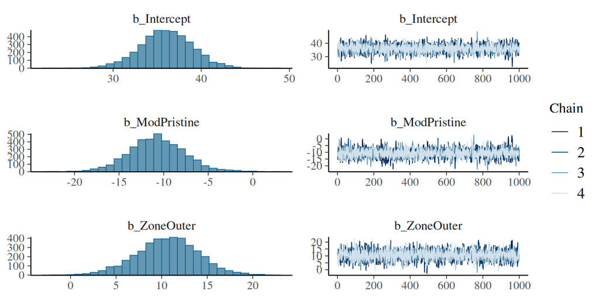

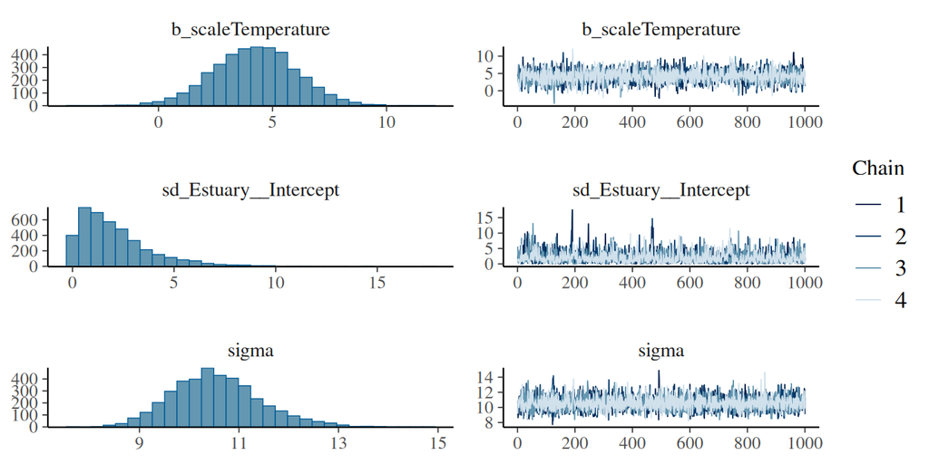

```r
plot(fit.zone.2)
```

With 3 predictors, we can plot against 2 while the 3rd is at its reference level

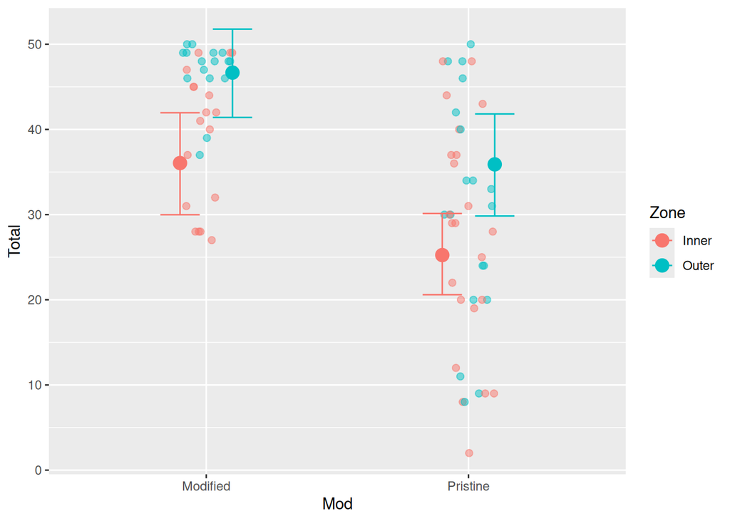

```r
plot(conditional_effects(fit.zone.2,
                         effect="Mod:Zone"), # Temperature=mean
     points=T,
     point_args=c(alpha=0.5, width=0.1))
```

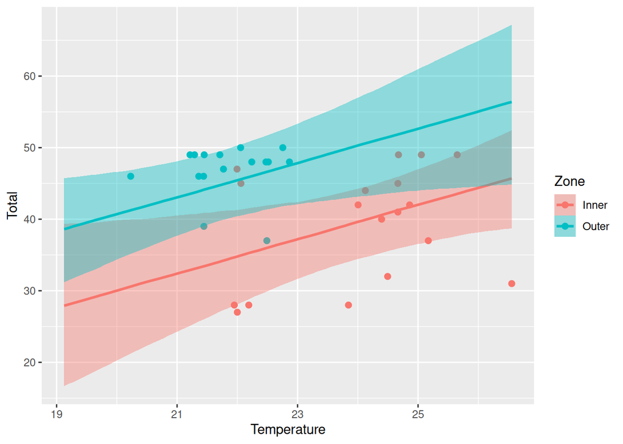

```r
plot(conditional_effects(fit.zone.2,
                         effect="Temperature:Zone"), # Mod=modified
     points=T)
```

Or we can plot against all 3

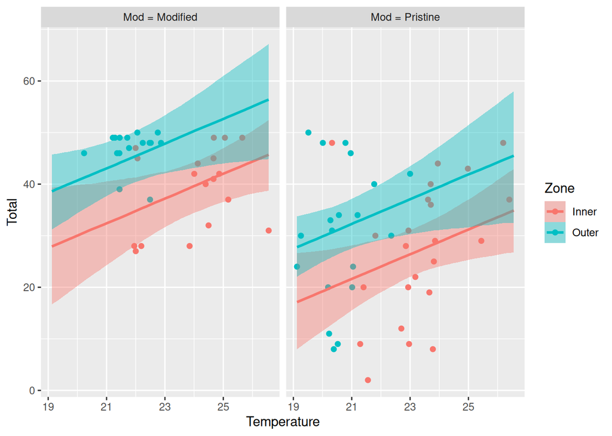

```r
plot(conditional_effects(fit.zone.2,
                         effect="Temperature:Zone",
                         conditions = make_conditions(fit.zone.2, var=c("Mod"))),
     points=T)
```

There is only very weak support for including temperature regarding predictive accuracy, but temperature effect is positive

```r
LOO(fit.zone.1, fit.zone.2)
```

```
           elpd_diff se_diff
fit.zone.2  0.0       0.0
fit.zone.1 -2.1       3.0
```

The direct effect of Zone is now 2x stronger when controlling for temperature! There are ~10 species more in the outer zone than in an inner zone of the same temperature. How can that happen??

```r
fixef(fit.zone.1)
```

```
              Estimate Est.Error        Q2.5     Q97.5
Intercept    39.470272  2.757911  33.5211542 44.668288
ModPristine -12.473993  3.275475 -18.6265579 -5.514716
ZoneOuter     5.151376  2.499280   0.2089617 10.108564
```

```r
fixef(fit.zone.2)
```

```
                  Estimate Est.Error        Q2.5     Q97.5
Intercept         36.04123  2.986821  29.9818478 41.958176
ModPristine      -10.75982  3.156734 -16.8988015 -4.380493
ZoneOuter         10.60718  3.433391   3.6634936 17.270785
scaleTemperature   4.23131  1.838677   0.5823119  7.806587
```

However, inner zones are usually warmer, so this difference is a rather pointless prediction!

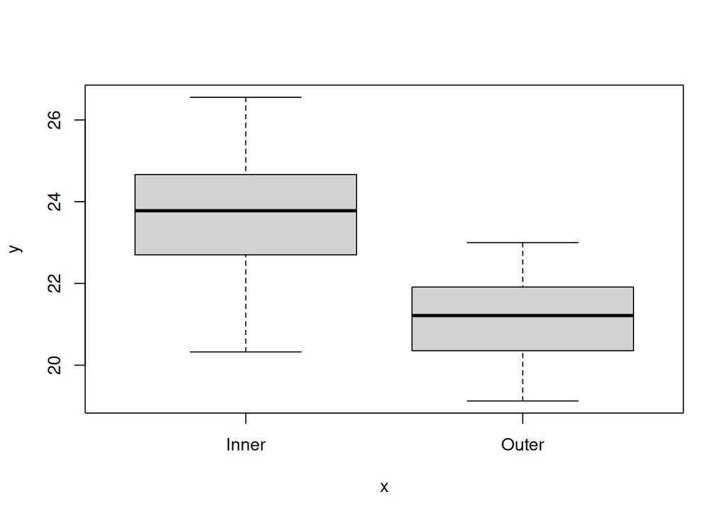

```r
plot(estuaryZone$Zone, estuaryZone$Temperature)
```

If interested in a meaningful difference, compare predictions between inner & outer zone at their typical temperatures.

```r
mus = fitted(fit.zone.2,
             newdata = data.frame(Zone=c("Inner", "Outer"),
                                  Temperature=c(23.5, 21.5),
                                  Mod=c("Modified", "Modified")),
             re_formula = NA, # only fixed effects prediction
             summary=FALSE
)
mus = data.frame(mus)
names(mus)=c("Inner","Outer")
hypothesis(mus, "Inner<Outer")
```

```
Hypothesis Tests for class :
           Hypothesis Estimate Est.Error CI.Lower CI.Upper Evid.Ratio Post.Prob Star
1 (Inner)-(Outer) < 0    -5.85      2.41    -9.78    -1.88      94.24      0.99    *
---
'CI': 90%-CI for one-sided and 95%-CI for two-sided hypotheses.
'*': For one-sided hypotheses, the posterior probability exceeds 95%;
for two-sided hypotheses, the value tested against lies outside the 95%-CI.
Posterior probabilities of point hypotheses assume equal prior probabilities.
```

This is much closer to the model without temperature, which actually would be sufficient here.

```r
hypothesis(fit.zone.1, c("ZoneOuter>0",
                         "ModPristine<0"))
```

```
Hypothesis Tests for class b:
         Hypothesis Estimate Est.Error CI.Lower CI.Upper Evid.Ratio Post.Prob Star
1   (ZoneOuter) > 0     5.15      2.50     1.09     9.17      47.78      0.98    *
2 (ModPristine) < 0   -12.47      3.28   -17.69    -6.89     799.00      1.00    *
---
'CI': 90%-CI for one-sided and 95%-CI for two-sided hypotheses.
'*': For one-sided hypotheses, the posterior probability exceeds 95%;
for two-sided hypotheses, the value tested against lies outside the 95%-CI.
Posterior probabilities of point hypotheses assume equal prior probabilities.
```

**Be careful if predictors are correlated.** Parameters only describe **direct** effect, meaning other predictors are held constant. Just looking at effect size, you might compare predictions which are very unlikely to occur in the data (Inner and Outer zone with same temperature).